# Homework 4

Stanley Chan

2026-01-18

## Instructions

Answer the following questions and/or complete the exercises in RMarkdown. Please embed all of your code and push the final work to your repository. Your report should be organized, clean, and run free from errors. Remember, you must remove the `#` for any included code chunks to run. Any plots must have appropriate titles and aesthetics.

## Load the tidyverse

```r
library("tidyverse")
options(scipen = 999) #disable scientific notation
```

For this homework, we will be using the `msleep` dataset from the `ggplot2` package. This dataset contains information about the sleep habits of various mammals. [Reference](https://ggplot2.tidyverse.org/reference/msleep.html): V. M. Savage and G. B. West. A quantitative, theoretical framework for understanding mammalian sleep. Proceedings of the National Academy of Sciences, 104 (3):1051-1056, 2007.

```r
msleep <- msleep
```

**1. Use a summary function of your choice to get an idea of the structure of the msleep data.**

```r
glimpse(msleep)
```

```
## Rows: 83
## Columns: 11
## $ name         <chr> "Cheetah", "Owl monkey", "Mountain beaver", "Greater shor…
## $ genus        <chr> "Acinonyx", "Aotus", "Aplodontia", "Blarina", "Bos", "Bra…
## $ vore         <chr> "carni", "omni", "herbi", "omni", "herbi", "herbi", "carn…
## $ order        <chr> "Carnivora", "Primates", "Rodentia", "Soricomorpha", "Art…
## $ conservation <chr> "lc", NA, "nt", "lc", "domesticated", NA, "vu", NA, "dome…
## $ sleep_total  <dbl> 12.1, 17.0, 14.4, 14.9, 4.0, 14.4, 8.7, 7.0, 10.1, 3.0, 5…
## $ sleep_rem    <dbl> NA, 1.8, 2.4, 2.3, 0.7, 2.2, 1.4, NA, 2.9, NA, 0.6, 0.8, …
## $ sleep_cycle  <dbl> NA, NA, NA, 0.1333333, 0.6666667, 0.7666667, 0.3833333, N…
## $ awake        <dbl> 11.9, 7.0, 9.6, 9.1, 20.0, 9.6, 15.3, 17.0, 13.9, 21.0, 1…
## $ brainwt      <dbl> NA, 0.01550, NA, 0.00029, 0.42300, NA, NA, NA, 0.07000, 0…
## $ bodywt       <dbl> 50.000, 0.480, 1.350, 0.019, 600.000, 3.850, 20.490, 0.04…
```

**2. What are the names of the variables? To get a better idea of what the variables mean, you can use `?msleep`.**

```r
names(msleep)
```

```
##  [1] "name"         "genus"        "vore"         "order"        "conservation"
##  [6] "sleep_total"  "sleep_rem"    "sleep_cycle"  "awake"        "brainwt"
## [11] "bodywt"
```

```r
?msleep
```

**3. Make a plot that shows the number of mammals in each vore type. Which vore type is most represented in the data?**

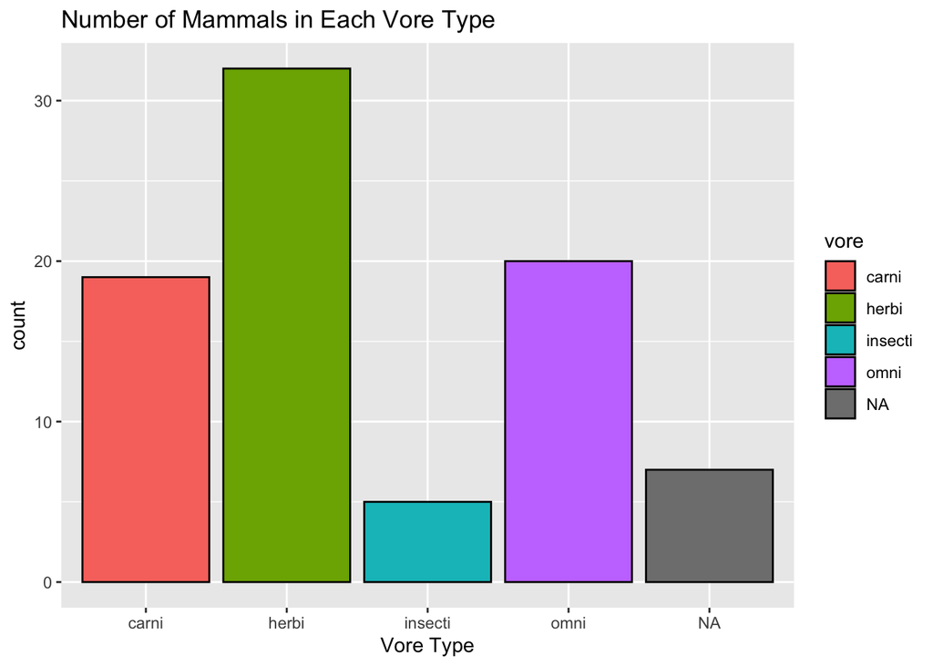

```r
ggplot(data = msleep,
       mapping = aes(x = vore))+
  geom_bar(mapping = aes(fill = vore),color="black")+
  labs(title="Number of Mammals in Each Vore Type", x="Vore Type")
```

The herbi vore type is the most represented mammal in this data.

**4. What is the average length of time that mammal sleeps?**

```r
mean(msleep$sleep_total)
```

```
## [1] 10.43373
```

**5. Use `summary()` to get a quick idea of the range of values for the variable `bodywt`.**

```r
summary(msleep$bodywt)
```

```
##     Min.  1st Qu.   Median     Mean  3rd Qu.     Max.
##    0.005    0.174    1.670  166.136   41.750 6654.000
```

**6. Build a plot that shows the range of `bodywt.` by vore type. Because the range of `bodywt` is so variable, you will need to scale the y-axis. You do this by adding `scale_y_log10()` as another layer.**

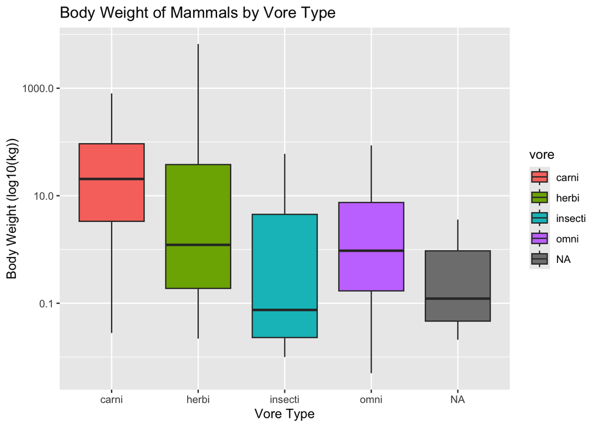

```r
ggplot(data = msleep,
       mapping = aes(x = vore, y = bodywt))+
  geom_boxplot(mapping = aes(fill = vore))+
  labs(title="Body Weight of Mammals by Vore Type", x = "Vore Type", y = "Body Weight (log10(kg))")+
  scale_y_log10()
```

**7. Is there a relationship between body weight and total sleep time? Add appropriate labels and a title to your plot.**

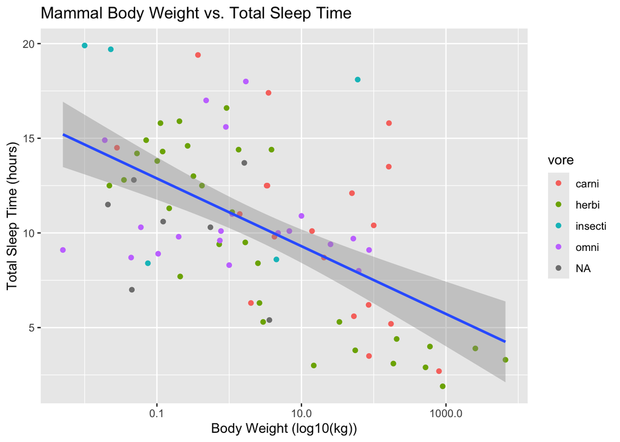

```r
ggplot(data = msleep,
       mapping = aes(x = bodywt, y = sleep_total))+
  geom_point(mapping=aes(color=vore))+
  geom_smooth(method=lm, se=T)+
  scale_x_log10()+
  labs(title="Mammal Body Weight vs. Total Sleep Time", x="Body Weight (log10(kg))", y="Total Sleep Time (hours)")
```

There is a negative relationship between body weight and total sleep time

**8. Which vore type tends to sleep the most? Build a plot to support your answer.**

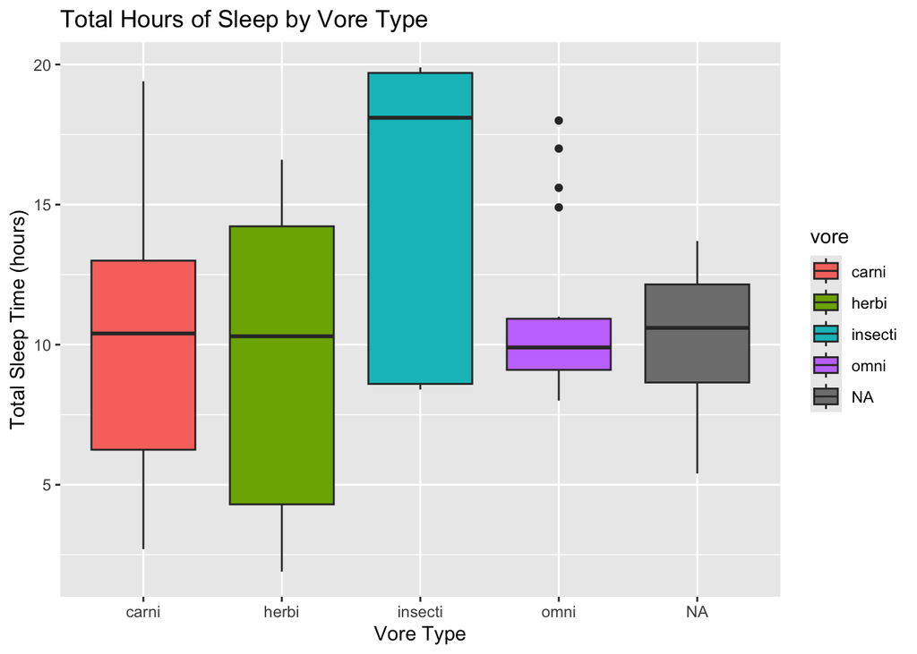

```r
ggplot(data=msleep,
       mapping=aes(x=vore, y=sleep_total))+
  geom_boxplot(mapping=aes(fill=vore))+
  labs(title="Total Hours of Sleep by Vore Type", x="Vore Type", y="Total Sleep Time (hours)")
```

The insecti vore type tends to sleep the most.

**9. Is there a relationship between brain weight and body weight? Build a plot to support your answer.**

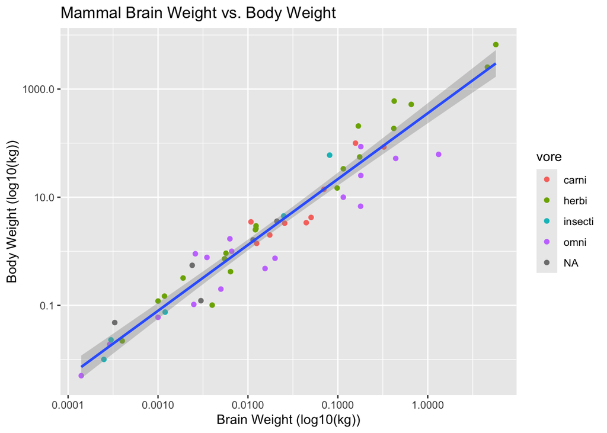

```r
ggplot(data=msleep,
       mapping=aes(x=brainwt, y=bodywt))+
  geom_point(mapping=aes(color=vore))+
  geom_smooth(method=lm, se=T)+
  scale_x_log10()+
  scale_y_log10()+
  labs(title="Mammal Brain Weight vs. Body Weight", x="Brain Weight (log10(kg))", y="Body Weight (log10(kg))")
```

There is a positive relationship with brain weight and body weight of mammals.

**10. Build one plot of your choice that provides additional insight into the msleep dataset. Be sure to include appropriate labels and a title.**

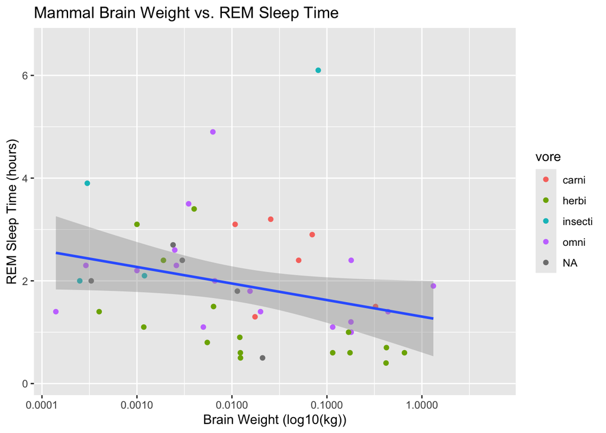

```r
ggplot(data=msleep,
       mapping=aes(x=brainwt, y=sleep_rem))+
  geom_point(mapping=aes(color=vore))+
  geom_smooth(method=lm, se=T)+
  scale_x_log10()+
  labs(title="Mammal Brain Weight vs. REM Sleep Time", x="Brain Weight (log10(kg))", y="REM Sleep Time (hours)")
```

## Knit and Upload

Please knit your work as an .html file and upload to Canvas. Homework is due before the start of the next lab. No late work is accepted. Make sure to use the formatting conventions of RMarkdown to make your report neat and clean!